# Predicting NFL Quarterback Ratings[^1]

A Least Squares Method and Linear Regression Implementation in R

by Arda Ugur, SeyedAli TaheriTari a_ugur1@u.pacific.edu, s_taheritari@u.pacific.edu University of the Pacific, School of Engineering and Computer Science, Ms. Sci. Data Science

September 2017

[figure not shown]

# 1 Introduction

[Quarterback rating](https://en.wikipedia.org/wiki/Passer_rating) (also known as **passer rating**, or **QB rating**) is a measure of the performance of passers, primarily quarterbacks, in American football. Quarterback rating is calculated using player’s passing attempts, completions, yards, touchdowns, and interceptions. Since 1973, passer rating has been the official formula used by the NFL to determine its passing leader. Passer rating in the NFL is on a scale from 0 to 158.3.

The main objective of this study is to provide an example of the **least squares method** in [R](https://en.wikipedia.org/wiki/Passer_rating) programming language, using the NFL quarterback rating (2008) data set.

# 2 Data Set

2008 NFL Quarterback Ratings

| First | Last | Team | Att | Comp | Pct Comp | Yds | Yds per Att | TD | Pct TD | Long | Int | Pct Int | Rating Pts |
| --- | --- | --- | --- | --- | --- | --- | --- | --- | --- | --- | --- | --- | --- |
| Philip | Rivers | SD | 478 | 312 | 65.3 | 4009 | 8.39 | 34 | 7.1 | 67 | 11 | 2.3 | 105.5 |
| Chad | Pennington | MIA | 476 | 321 | 67.4 | 3653 | 7.67 | 19 | 4.0 | 80 | 7 | 1.5 | 97.4 |
| Kurt | Warner | ARI | 598 | 401 | 67.1 | 4583 | 7.66 | 30 | 5.0 | 79 | 14 | 2.3 | 96.9 |
| Drew | Brees | NO | 635 | 413 | 65.0 | 5069 | 7.98 | 34 | 5.4 | 84 | 17 | 2.7 | 96.2 |
| Peyton | Manning | IND | 555 | 371 | 66.8 | 4002 | 7.21 | 27 | 4.9 | 75 | 12 | 2.2 | 95.0 |
| Aaron | Rodgers | GB | 536 | 341 | 63.6 | 4038 | 7.53 | 28 | 5.2 | 71 | 13 | 2.4 | 93.8 |
| Matt | Schaub | HOU | 380 | 251 | 66.1 | 3043 | 8.01 | 15 | 3.9 | 65 | 10 | 2.6 | 92.7 |
| Tony | Romo | DAL | 450 | 276 | 61.3 | 3448 | 7.66 | 26 | 5.8 | 75 | 14 | 3.1 | 91.4 |
| Jeff | Garcia | TB | 376 | 244 | 64.9 | 2712 | 7.21 | 12 | 3.2 | 71 | 6 | 1.6 | 90.2 |
| Matt | Cassel | NE | 516 | 327 | 63.4 | 3693 | 7.16 | 21 | 4.1 | 76 | 11 | 2.1 | 89.4 |
| Matt | Ryan | ATL | 434 | 265 | 61.1 | 3440 | 7.93 | 16 | 3.7 | 70 | 11 | 2.5 | 87.7 |
| Shaun | Hill | SF | 288 | 181 | 62.8 | 2046 | 7.10 | 13 | 4.5 | 48 | 8 | 2.8 | 87.5 |
| Seneca | Wallace | SEA | 242 | 141 | 58.3 | 1532 | 6.33 | 11 | 4.5 | 90 | 3 | 1.2 | 87.0 |
| Eli | Manning | NYG | 479 | 289 | 60.3 | 3238 | 6.76 | 21 | 4.4 | 48 | 10 | 2.1 | 86.4 |
| Donovan | McNabb | PHI | 571 | 345 | 60.4 | 3916 | 6.86 | 23 | 4.0 | 90 | 11 | 1.9 | 86.4 |
| Jay | Cutler | DEN | 616 | 384 | 62.3 | 4526 | 7.35 | 25 | 4.1 | 93 | 18 | 2.9 | 86.0 |
| Trent | Edwards | BUF | 374 | 245 | 65.5 | 2699 | 7.22 | 11 | 2.9 | 65 | 10 | 2.7 | 85.4 |
| Jake | Delhomme | CAR | 414 | 246 | 59.4 | 3288 | 7.94 | 15 | 3.6 | 65 | 12 | 2.9 | 84.7 |
| Jason | Campbell | WAS | 506 | 315 | 62.3 | 3245 | 6.41 | 13 | 2.6 | 67 | 6 | 1.2 | 84.3 |
| David | Garrard | JAC | 535 | 335 | 62.6 | 3620 | 6.77 | 15 | 2.8 | 41 | 13 | 2.4 | 81.7 |
| Brett | Favre | NYJ | 522 | 343 | 65.7 | 3472 | 6.65 | 22 | 4.2 | 56 | 22 | 4.2 | 81.0 |
| Joe | Flacco | BAL | 428 | 257 | 60.0 | 2971 | 6.94 | 14 | 3.3 | 70 | 12 | 2.8 | 80.3 |
| Kerry | Collins | TEN | 415 | 242 | 58.3 | 2676 | 6.45 | 12 | 2.9 | 56 | 7 | 1.7 | 80.2 |
| Ben | Roethlisberger | PIT | 469 | 281 | 59.9 | 3301 | 7.04 | 17 | 3.6 | 65 | 15 | 3.2 | 80.1 |
| Kyle | Orton | CHI | 465 | 272 | 58.5 | 2972 | 6.39 | 18 | 3.9 | 65 | 12 | 2.6 | 79.6 |
| JaMarcus | Russell | OAK | 368 | 198 | 53.8 | 2423 | 6.58 | 13 | 3.5 | 84 | 8 | 2.2 | 77.1 |
| Tyler | Thigpen | KC | 420 | 230 | 54.8 | 2608 | 6.21 | 18 | 4.3 | 75 | 12 | 2.9 | 76.0 |
| Gus | Frerotte | MIN | 301 | 178 | 59.1 | 2157 | 7.17 | 12 | 4.0 | 99 | 15 | 5.0 | 73.7 |
| Dan | Orlovsky | DET | 255 | 143 | 56.1 | 1616 | 6.34 | 8 | 3.1 | 96 | 8 | 3.1 | 72.6 |
| Marc | Bulger | STL | 440 | 251 | 57.0 | 2720 | 6.18 | 11 | 2.5 | 80 | 13 | 3.0 | 71.4 |
| Ryan | Fitzpatrick | CIN | 372 | 221 | 59.4 | 1905 | 5.12 | 8 | 2.2 | 79 | 9 | 2.4 | 70.0 |
| Derek | Anderson | CLE | 283 | 142 | 50.2 | 1615 | 5.71 | 9 | 3.2 | 70 | 8 | 2.8 | 66.5 |

# 3 Objectives

- **Objective 1** : Create a least squares model to relate the dependent variable **quarterback rating** to the **percentage of completions**.
- **Objective 2** : Create a least squares model to relate the dependent variable **quarterback rating** to the **percentage of completions** and **percentage of interceptions**.
- **Objective 3** : Determine the **least squares error** (or the *square root of sum of squared errors*) for models in **Objective 1** and **Objective 2**. Comment on whether using an additional variable (i.e., the percentage of interceptions) improves the accuracy of the linear regression model for the given data set.
- **Objective 4** : Using models from **Objective 1** and **Objective 2** predict the **quarterback rating** for 60% completion and 3% interception rates.
- **Objective 5** : Go Seahawks!

# 4 Mathematical Preliminaries

Regression analysis is a conceptually simple method for investigating functional relationships among two or more variables. For example, a civil engineer may wish to relate a specific mixture of concrete specimen’s compressive strength to its other physical or mechanical attributes (e.g., compressive strength versus density, air content, water/cement ratio, etc.) Or an economist may wish to investigate the relationship between the economic structure and environmental pollution level of a country or a region.  
The investigated relationship is usually expressed in the form of an equation or a model connecting the **response** (or **dependent**) **variable** and one or more **explanatory** or **predictor variables**.We denote the response variable $Y$ and the set of predictor variables by $X_1$, $X_2$, …, $X_p$, where $p$ denotes the number of predictor variables. The **true** relationship between $Y$ and $X_1$, $X_2$, ,$X_p$ can be approximated by the following regression model:

$$Y=f(X_1, X_2, \dots, X_p) + \epsilon$$
where $\epsilon$ is assumed to be a random error representing the discrepancy in the approximation. It accounts for the failure of the model to fit the data exactly. The function $f(X_1, X_2, ..., X_p)$ describes the relationship between $Y$ and $X_1$, $X_2$,, $X_p$. An example to such relationship is the **linear regression model** which can be expressed as:

$$Y= \beta_0 + \beta_1X_1 + \beta_2X_2 +\dots + \beta_pX_p + \epsilon$$
where $\beta_0, \beta_1, \beta_2,\dots,\beta_p$, (called the **regression parameters** or **regression coefficients**), are basically the unknown constants to be estimated from the data.
We can represent **simple** and **multiple regression models** in matrix notation as well. To do so, first, let us define the following matrices:

$$\begin{equation}
Y = \begin{bmatrix}
y_1 \\
y_2\\
y_3\\
\vdots\\
y_n
\end{bmatrix}
\space\space\space\space\
X = \begin{bmatrix}
1 & x_{11} & x_{12} & \dots & x_{1p}\\
1 & x_{21} & x_{22} & \dots & x_{2p}\\
1 & x_{31} & x_{32} & \dots & x_{3p}\\
\vdots & \vdots & \vdots & & \vdots\\
1 & x_{n1} & x_{n2} & \dots & x_{np}\\
\end{bmatrix}
\space\space\space\space\
\beta = \begin{bmatrix}
\beta_0\\
\beta_1\\
\beta_2\\
\vdots\\
\beta_p
\end{bmatrix}
\space\space\space\space\
\epsilon = \begin{bmatrix}
\epsilon_1\\
\epsilon_2\\
\epsilon_3\\
\vdots\\
\epsilon_p
\end{bmatrix}
\end{equation}$$

so that we can express linear regression models like $Y= \beta_0 + \beta_1X_1 + \beta_2X_2 +\dots + \beta_pX_p + \epsilon$ in terms of systems of linear equations.

$$Y = X\beta + \epsilon$$
This approach allows us to utilize numerical and computer methods to solve such systems with multiple unknowns and multiple number of equations.

The least squares estimator $\widehat{\beta}$ of $\beta$ is obtained by minimizing the SSE (**Sum of Squared Errors** or the sum of squared deviations of the observations from their expected values) as below:

$$SSE=\epsilon_1^2+\epsilon_2^2+...+\epsilon_p^2$$
Consequently, in the matrix notation, the least squares estimators are obtained by minimizing $S(\beta)$, where
$$S(\beta) = \epsilon^T\epsilon = (Y - X\beta)^T(Y - X\beta)$$
Since we can only estimate $\beta$, minimization of $S(\beta)$ takes us to the system of equations
$$(X^TX)\widehat{\beta} = X^TY$$
And finally, provided that $X^TX$ is invertible, the **least squares estimate** $\widehat{\beta}$ can be written as:
$$\widehat{\beta}=(X^TX)^{-1}X^TY$$
The R language implementation of the given objectives will be based on the mathematical preliminaries summarized in this section. For more detailed information on the mathematical foundations of linear regression analysis, please refer to the references listed at the end of this document.

# 5 The R Implementation

In the following subsections, we are going to implement the mathematical principals of linear regression analysis, using the R programming language, in order to find meaningful answers to the questions stated earlier.

## 5.1 Objective 1

Let us create a least squares model to relate the response variable **quarterback rating** to the **percentage of completions** as follows:

$$\begin{equation}
\begin{bmatrix}
1 & 65.3\\
1 & 67.4\\
1 & 67.1\\
\vdots\\
1 & 50.2\\
\end{bmatrix}
\begin{bmatrix}
\beta_0 \\
\beta_1\\
\end{bmatrix}
+
\begin{bmatrix}
\epsilon_1\\
\epsilon_2\\
\epsilon_3\\
\vdots\\
\epsilon_p
\end{bmatrix}
=
\begin{bmatrix}
105.5\\
97.4\\
96.9\\
\vdots\\
66.5
\end{bmatrix}
\end{equation}$$

Using `ginv` function, we are going to compute the vector for $\beta$ that consists of regression coefficients $\beta_0$ and $\beta_1$

```
## [1] "Regression Coefficients for Quarterback Rating Points based on Percentage of Completions:"
```

```
##         [,1]
## [1,] -22.033
## [2,]   1.746
```

Now, let us compute the predicted values of **Quarterback Rating Points** $(\widehat{Y})$, using $X$ and computed $\widehat{\beta}$ values

```
## [1] "Predicted Quarterback Rating Points:"
```

```
##         [,1]
##  [1,] 91.956
##  [2,] 95.622
##  [3,] 95.098
##  [4,] 91.433
##  [5,] 94.575
##  [6,] 88.989
##  [7,] 93.353
##  [8,] 84.974
##  [9,] 91.258
## [10,] 88.640
## [11,] 84.625
## [12,] 87.592
## [13,] 79.737
## [14,] 83.228
```

[output cut: 18 more lines]

Since we have obtained the predicted **Quarterback Rating Points** values, we now can compute the **Residuals** and the **Least Squares Errors** as follows:

```
## [1] "Deviation between predicted and observed Quarterback Rating Points:"
```

```
##          [,1]
##  [1,]  13.544
##  [2,]   1.778
##  [3,]   1.802
##  [4,]   4.767
##  [5,]   0.425
##  [6,]   4.811
##  [7,]  -0.653
##  [8,]   6.426
##  [9,]  -1.058
## [10,]   0.760
## [11,]   3.075
## [12,]  -0.092
## [13,]   7.263
## [14,]   3.172
```

[output cut: 18 more lines]

As the Sqareroot of **Sum of Squared Errors** or the **Residuals Vector** constitutes the least squares error, we will use `norm` function to compute the length of residuals vector

```
## [1] "The least squares error is 29.582"
```

We can also plot the observed Quarterback ratings against the predicted values along with a best fit line using `plot` and `line` functions

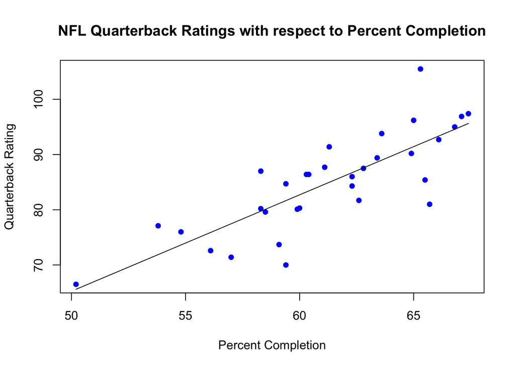

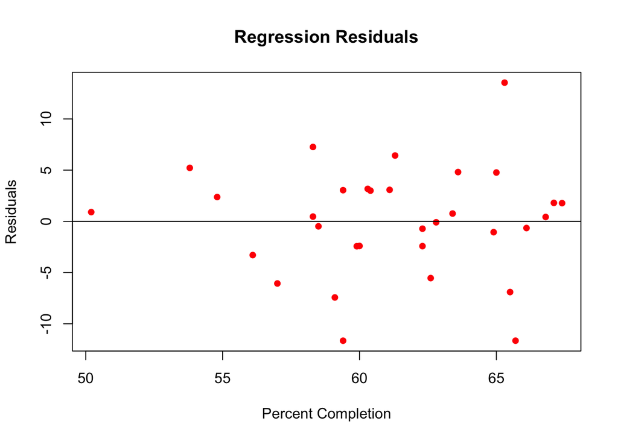

## 5.2 Objective 2

Let us create a multiple linear regression model to relate the response variable **Quarterback Rating** to the **Percentage of Completions** and **Percentage of Interceptions** as follows:

$$\begin{equation}
\begin{bmatrix}
1 & 65.3 & 2.3\\
1 & 67.4 & 1.5\\
1 & 67.1 & 2.3\\
\vdots\\
1 & 50.2 & 2.8\\
\end{bmatrix}
\begin{bmatrix}
\beta_0 \\
\beta_1\\
\beta_2\\
\end{bmatrix}
+
\begin{bmatrix}
\epsilon_1\\
\epsilon_2\\
\epsilon_3\\
\vdots\\
\epsilon_p
\end{bmatrix}
=
\begin{bmatrix}
105.5\\
97.4\\
96.9\\
\vdots\\
66.5
\end{bmatrix}
\end{equation}$$

As before, by using `ginv` function, we are going to compute the $\beta$ vector for regression coefficients $\beta_0$, $\beta_1$, and $\beta_2$

```
## [1] "Regression Coefficients for Quarterback Rating Points ~ Percentage of Completions and ~ Percentage of Interceptions:"
```

```
##        [,1]
## [1,] -9.109
## [2,]  1.662
## [3,] -3.076
```

After regression coefficients are obtained, we can compute the predicted values of **Quarterback Rating Points** $(\widehat{Y})$, in relation to **Percentage of Completions** and **Percentage of Interceptions**:

```
## [1] "Predicted Quarterback Rating Points:"
```

```
##         [,1]
##  [1,] 92.355
##  [2,] 98.307
##  [3,] 95.347
##  [4,] 90.626
##  [5,] 95.156
##  [6,] 89.222
##  [7,] 92.762
##  [8,] 83.245
##  [9,] 93.844
## [10,] 89.812
## [11,] 84.759
## [12,] 86.662
## [13,] 84.104
## [14,] 84.660
```

[output cut: 18 more lines]

Since we obtained the predicted values above, we can compute the **Residuals** and the **Least Squares Error** as follows:

```
## [1] "Deviation between predicted and observed Quarterback Rating Points:"
```

```
##          [,1]
##  [1,]  13.145
##  [2,]  -0.907
##  [3,]   1.553
##  [4,]   5.574
##  [5,]  -0.156
##  [6,]   4.578
##  [7,]  -0.062
##  [8,]   8.155
##  [9,]  -3.644
## [10,]  -0.412
## [11,]   2.941
## [12,]   0.838
## [13,]   2.896
## [14,]   1.740
```

[output cut: 18 more lines]

As the sqareroot of sum of squared errors or the residuals vector constitutes the least squares error, we will use `norm` function to compute the length of residuals vector

```
## [1] "The least squares error is 26.581"
```

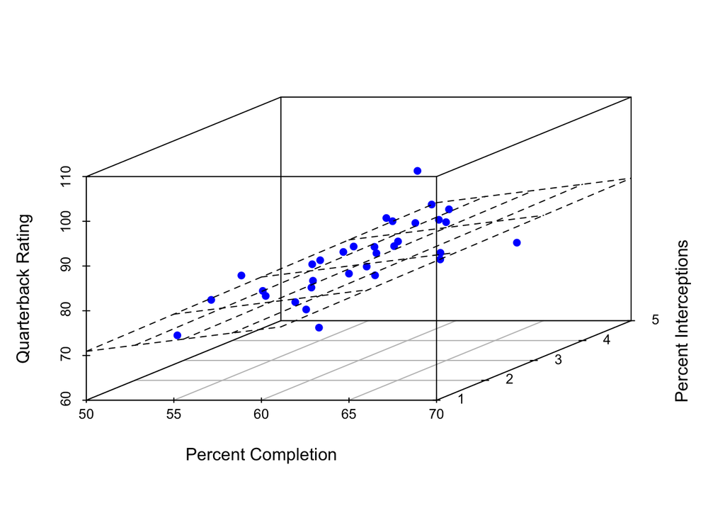

## 5.3 Objective 3

As we determined the **Least Square Errors** (square root of sum of squared errors) for each regression model in previous subsections (under Objective 1 and Objective 2), we now can discuss whether using an additional variable has improved the accuracy of the regression model for the data set in question.

Let us first revisit the least squares errors for each regression model developed earlier.

```
## [1] "The least squares error for simple linear regression is 29.582"
```

```
## [1] "The least squares error for multiple linear regression model is 26.581"
```

As it is the objective of linear regression to **minimize** the square root of residuals, (and ignoring other regression diagnostic measures within the scope of this assignment) we can observe that the second model which is built on two predictor variables, has less deviation from the actual observed values; and consequently, has a smaller sum of squared errors. Based on this observation, we can -and without looking at other regression diagnostic measures- we can surmise that building a regression model with more variables tend to approximate observed values with smaller error.

## 5.4 Objective 4

Using the linear regression models developed in objectives (1) and (2) in repsectively, we can predict the quarterback rating points for percentage of completions of 60% and percentage of interceptions of 3%.

However, let us start with writing our regression models out below, before plugging in the numbers:

```
## [1] "Beta values for simple linear model:"
```

```
##         [,1]
## [1,] -22.033
## [2,]   1.746
```

```
## [1] "Beta values for multiple linear model:"
```

```
##        [,1]
## [1,] -9.109
## [2,]  1.662
## [3,] -3.076
```

$$\widehat{Y_a}=-22.033 + 1.746X_1$$
and

$$\widehat{Y_b}=-9.109 + 1.662X_1 -3.076X_2$$
For the simple linear model, using only the percent of completions (60%), we predict that the quarterback rating point will be:

```
## [1] "For 60 percent completion rate, the quarterback rating is estimated to be 82.705"
```

For the multiple linear model, using the percent of completions (60%) and percent of intercept (3%), we predict that the quarterback rating point will be:

```
## [1] "For 60 percent completion rate and 3 percent interception rate, the quarterback rating is estimated to be 81.392"
```

## 5.5 Objective 5

[figure not shown]

# 6 Further Study

Let us try to use the R **lm()** package and compare the results obtained from **lm()** package to the desired values we computed above.

```r
library(MASS)
library(ISLR)
```

**Simple Linear Regression Using lm() Package**

```
## [1] "Regression Coefficients for Simple Model (Percentage of Completions vs. Quarterback Ratings"
```

```
##
## Call:
## lm(formula = response ~ predictor, data = qbrating_matrix)
##
## Coefficients:
## (Intercept)    predictor
##     -22.033        1.746
```

```
## [1] "Regression Coefficients for Multiple Model (Percentage of Completions and Percentage of Interceptions vs. Quarterback Ratings"
```

```
##
## Call:
## lm(formula = response ~ predictor + predictor2, data = qbrating_matrix)
##
## Coefficients:
## (Intercept)    predictor   predictor2
##      -9.109        1.662       -3.076
```

The results provided above, shows that the regression coefficients computed by the authors, conforms to those of produced by the **lm() package** of the R programming language.

# 7 References

1. Zarei, A. (2017), *Linear Algebra for Data Science - Lecture Notes*, University of the Pacific, School of Engineering and Computer Science, Stockton, CA.
2. Chatterjee, S., and Hadi, A. S. (2012), *Regression Analysis by Example*, 5th ed., New Jersey: John Wiley & Sons.
3. James, G., Witten, D., Hastie, T., Tibshirani, R. (2013), *An Introduction to Statistical Learning with Applications in R*, 6th printing (2015), New York, Springger Science+Business Media.
4. Davies, T. M. (2016), *The Book of R: A First Course in Programming and Statistics*, 1st ed., San Francisco: No Starch Press.

# 8 Acknowledgements

The authors wish to thank Dr. A. Zarei for providing guidence and help during the process of completion of this research project.

[^1]: ANLT-201 - Linear Algebra for Data Science / Assignment 01